# 2. 데이터 EDA

#### - 차원축소 없이 K-Means

차원축소(PCA) 후 DBSCAN을 사용하는 것은, 분석가가 직접 눈으로 확인하면서 유의미한 클러스터를 직접 도출 가능하는 점에서 장점이 있다.

그러나, 차원축소(PCA) 과정에서 설명력(분산)의 59%를 손실해버렸다. 다시 말해, 유의미한 정보를 담았을 수도 있는 축이 인간이 3차원까지만 인식 가능하다는 한계때문에 유실된 것이다.

#### 시각화 하기 위해 차원축소를 하지 않고, 고차원(107차원)의 데이터셋에 대하여 직접 K-Means를 실시한다.

```python
def visualize_elbowmethod(data, param_init='random', param_n_init=10, param_max_iter=300):
    distortions = []
    for i in range(1, 20):
        km = KMeans(n_clusters=i, init=param_init, n_init=param_n_init, max_iter=param_max_iter, random_state=42)
        km.fit(data)
        distortions.append(km.inertia_)
    plt.plot(range(1, 20), distortions, marker='o')
    plt.xlabel('Number of Cluster')
    plt.ylabel('Distortion')
    plt.show()
```

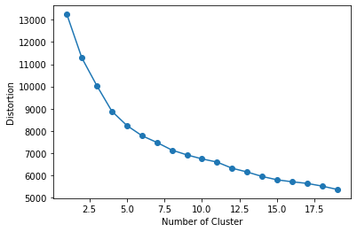

```python
visualize_elbowmethod(category_frequency_labeling_scailing.iloc[:,1:])
```

각 클러스터의 집단내 분산의 합을 이용하는 Elbow 기법을 활용했을 때, 꺾이는 부분이 딱히 존재하진 않다.

다만, 기울기가 줄어드는 지점은 네번째 점, 즉 클러스터 갯수 4개일때로 보인다.

```python
kmeans = KMeans(n_clusters = 4)
```

```python
cluster = kmeans.fit_predict(category_frequency_labeling_scailing.iloc[:,1:])
```

```python
#각 클러스터별 갯수
Series(cluster).value_counts()
```

```
1    4326
2    1146
0    1047
3    1030
dtype: int64
```

```python
category_frequency_labeling_scailing_cluster = category_frequency_labeling_scailing.copy()
```

```python
category_frequency_labeling_scailing_cluster['cluster_kmeans'] = cluster
```

```python
cluster_0 = category_frequency_labeling_scailing_cluster[
    category_frequency_labeling_scailing_cluster['cluster_kmeans'] == 0].iloc[:,1:-1]

cluster_0_power = pd.merge(Series(cluster_0.sum().sort_values(ascending=False), name = 'frequency'),
         Series(cluster_0.cumsum().iloc[-1,:] / cluster_0.shape[0], name = 'power'),
         left_index = True, right_index = True)

cluster_0_power[cluster_0_power['power'] > 0.1]
```

|  | frequency | power |
| --- | --- | --- |
| MEN | 982.029887 | 0.937946 |
| TOPS | 668.659202 | 0.638643 |
| Tees | 463.318358 | 0.442520 |
| BOTTOMS | 305.509816 | 0.291795 |
| WOMEN | 274.132267 | 0.261826 |
| OUTWEAR | 234.209011 | 0.223695 |
| Hoodie/Sweatshirts | 233.409684 | 0.222932 |
| Pants | 232.387009 | 0.221955 |
| Cotton pants | 172.933141 | 0.165170 |
| Knitwear | 145.232130 | 0.138713 |
| SHOES&ACC | 117.528948 | 0.112253 |

클러스터 0는 남성이 우위인 가운데 남녀 의류가 혼합되어 있다.

```python
cluster_1 = category_frequency_labeling_scailing_cluster[
    category_frequency_labeling_scailing_cluster['cluster_kmeans'] == 1].iloc[:,1:-1]

cluster_1_power = pd.merge(Series(cluster_1.sum().sort_values(ascending=False), name = 'frequency'),
         Series(cluster_1.cumsum().iloc[-1,:] / cluster_1.shape[0], name = 'power'),
         left_index = True, right_index = True)

cluster_1_power[cluster_1_power['power'] > 0.1]
```

|  | frequency | power |
| --- | --- | --- |
| WOMEN | 4301.185003 | 0.994264 |
| TOPS | 1761.896493 | 0.407281 |
| OUTWEAR | 971.651640 | 0.224607 |
| DRESSES/SETS | 886.711048 | 0.204973 |
| Tees | 875.194326 | 0.202310 |
| BOTTOMS | 869.208274 | 0.200927 |
| Knitwear | 618.352388 | 0.142939 |
| SHOES&ACC | 521.624801 | 0.120579 |
| Dresses | 464.609835 | 0.107399 |
| Round T-shirts | 456.457084 | 0.105515 |
| Pants | 442.907516 | 0.102383 |

클러스터 1는 여성복 위주로 묶여있다.

```python
cluster_2 = category_frequency_labeling_scailing_cluster[
    category_frequency_labeling_scailing_cluster['cluster_kmeans'] == 2].iloc[:,1:-1]

cluster_2_power = pd.merge(Series(cluster_2.sum().sort_values(ascending=False), name = 'frequency'),
         Series(cluster_2.cumsum().iloc[-1,:] / cluster_2.shape[0], name = 'power'),
         left_index = True, right_index = True)

cluster_2_power[cluster_2_power['power'] > 0.1]
```

|  | frequency | power |
| --- | --- | --- |
| KIDS | 1135.355026 | 0.990711 |
| Dresses/Sets | 326.279579 | 0.284712 |
| Tees | 313.160098 | 0.273264 |
| Sets | 289.309152 | 0.252451 |
| Tops | 278.418182 | 0.242948 |
| WOMEN | 273.766112 | 0.238888 |
| Pants | 261.737616 | 0.228392 |
| Bottoms | 240.413045 | 0.209785 |
| Shoes/Acc | 193.635444 | 0.168966 |
| Accessories | 167.360233 | 0.146039 |
| TOPS | 127.168290 | 0.110967 |
| SHOES&ACC | 115.031354 | 0.100376 |

클러스터2는 아동복 위주로 묶여있다

```python
cluster_3 = category_frequency_labeling_scailing_cluster[
    category_frequency_labeling_scailing_cluster['cluster_kmeans'] == 3].iloc[:,1:-1]

cluster_3_power = pd.merge(Series(cluster_3.sum().sort_values(ascending=False), name = 'frequency'),
         Series(cluster_3.cumsum().iloc[-1,:] / cluster_3.shape[0], name = 'power'),
         left_index = True, right_index = True)

cluster_3_power[cluster_3_power['power'] > 0.1]
```

|  | frequency | power |
| --- | --- | --- |
| SHOES&ACC | 998.286852 | 0.969211 |
| Accessories | 414.667352 | 0.402590 |
| WOMEN | 318.688942 | 0.309407 |
| SHOES | 287.438344 | 0.279066 |
| Jewelry | 217.298081 | 0.210969 |
| Bag | 213.461622 | 0.207244 |
| etc | 192.911945 | 0.187293 |
| Jewelry / Watches | 165.729201 | 0.160902 |
| TOPS | 118.284551 | 0.114839 |

클러스터3은 악세서리, 신발, 잡화 등으로 묶여있다.

#### 소결론 : PCA + DBSCAN, LDA Topic Modeling 두 알고리즘의 클러스터링 결과를 기준으로 비춰봤을 때,

#### 우리 고객은 크게 네 가지 분류로 분류가 가능하며 각각

#### - 남성복 / 여성복 동시 취급

#### - 여성복 중심 취급

#### - 아동복 중심 취급

#### - 신발 / 잡화 중심 취급

#### 으로 나눌 수 있다.

# 3. Modeling

## 1) Matrix Factorization

### (1) Singular Value Decomposition

#### 우선 가장 빠르면서 간단한 SVD를 활용한 행렬 분해 후, 일부 성분만 뽑아 재조합하여 코사인 유사도를 구한다.

#### - 평점 매트릭스 LOAD 및 전처리

```python
category_frequency_labeling = pd.read_csv('category_frequency_labeling.csv')
```

```python
category_frequency_labeling_scailing = category_frequency_labeling.apply(lambda x : min_max_scailing(x, 'buyerId'), axis = 1)

category_frequency_labeling_scailing = pd.concat(category_frequency_labeling_scailing.values.tolist())
```

```python
category_frequency_labeling_scailing_dropna = category_frequency_labeling_scailing[
                                        category_frequency_labeling_scailing['nan'] < 1]
```

```python
category_frequency_labeling_id = category_frequency_labeling_scailing['buyerId'][category_frequency_labeling_scailing['nan'] < 1]
```

```python
category_frequency_labeling_scailing = category_frequency_labeling_scailing.iloc[:,1:]

category_frequency_labeling_scailing = category_frequency_labeling_scailing.astype('float')
```

```python
#order_matrix_stack = order_matrix.groupby('buyerId')['id'].value_counts().unstack().fillna(0)
```

#### - SVD

```python
u,s,v = np.linalg.svd(category_frequency_labeling_scailing.to_numpy(), full_matrices = False)
```

특이값의 총합, 즉 에너지가 90%가 넘는 지점의 축을 도출한다.

```python
np.max(np.where(s.cumsum() / s.sum() < 0.9))
```

```
53
```

위에서 도출한 값을 토대로 상위 53개 특이값에 해당하는 축들을 뽑아 재조합한다.

```python
order_matrix_reconstruct = np.dot(u[:,0:53], np.dot(np.diag(s[0:53]), v[0:53]))
```

```python
csm = cosine_similarity(order_matrix_reconstruct)
```

User - User Matrix Factorization에 기반한 카테고리 유사도 판정 함수를 정의한다.

<파라미터>

1. ind : 타겟 유저 번호(1 ~ 7549)
2. csm : 코사인 유사도 매트릭스
3. k : Top - K번째 유저 정의

<도출값>

1. 코사인 유사도
2. Top - K 유저의 카테고리 목록
3. 타겟 유저와 Top - K 유저의 카테고리 목록 간 교집합
4. 도출된 Top - K 유저의 구매 상품 리스트

```python
def user_user_factorization(ind, csm, k):
    print('<1. cosine similarity>')
    for num in np.argsort(csm[ind])[-k:-1][::-1]:
        print(f'userID : {num} - ', csm[ind][num])
    print('\n')
    print("<2. Top - K user's Category list>")
    print(f'target - {ind}',
          set(category_frequency_labeling_scailing.columns[np.where(category_frequency_labeling_scailing.iloc[ind] > 0)]))
    for num in np.argsort(csm[ind])[-k:-1][::-1]:
        print(f'UserID - {num}',
              set(category_frequency_labeling_scailing.columns[np.where(category_frequency_labeling_scailing.iloc[num] > 0)]))
    print('\n')
    print("<3. Top - K User's intersection List>")
    for num in np.argsort(csm[ind])[-k:-1][::-1]:
        print(f'UserID - {num}',
        set(category_frequency_labeling_scailing.columns[np.where(category_frequency_labeling_scailing.iloc[ind] > 0)]).intersection(
        set(category_frequency_labeling_scailing.columns[np.where(category_frequency_labeling_scailing.iloc[num] > 0)])))
    print('\n')
    print("<4. Top - K User's Product List>")
    print(f'target - {ind}', "\n",
        pd.unique(product_json[product_json['buyerId'] == category_frequency_labeling.iloc[ind,0]]['name']), "\n")
    for num in np.argsort(csm[ind])[-k:-1][::-1]:
        print(f'UserID - {num}',"\n",
             pd.unique(product_json[product_json['buyerId'] == category_frequency_labeling.iloc[num,0]]['name']),"\n")
```

```python
user_user_factorization(162, csm, 10)
```

```
<1. cosine similarity>
userID : 2890 -  0.9676224926523769
userID : 3307 -  0.9472431844988184
userID : 3969 -  0.9280667210801746
userID : 5349 -  0.8935156348822644
userID : 5121 -  0.8722230291129957
userID : 4408 -  0.8722230291129957
userID : 1377 -  0.8716077818139484
userID : 2054 -  0.8560259340250752
userID : 3390 -  0.8530058496929763


<2. Top - K user's Category list>
target - 162 {'BOTTOMS', 'Cotton pants', 'MEN', 'BIG SIZE', 'WOMEN', 'Pants'}
UserID - 2890 {'BOTTOMS', 'Cotton pants', 'Knit Bottoms', 'BIG SIZE', 'WOMEN', 'Pants'}
UserID - 3307 {'BIG SIZE', 'WOMEN', 'BOTTOMS'}
UserID - 3969 {'BIG SIZE', 'WOMEN', 'BOTTOMS', 'Leggings'}
UserID - 5349 {'WOMEN', 'BIG SIZE', 'Sets', 'BOTTOMS'}
UserID - 5121 {'DRESSES', 'BIG SIZE', 'WOMEN', 'BOTTOMS'}
UserID - 4408 {'DRESSES', 'BIG SIZE', 'WOMEN', 'BOTTOMS'}
UserID - 1377 {'Slacks', 'DRESSES/SETS', 'Sets', 'BOTTOMS', 'Parkas', 'SHOES&ACC', 'DRESSES', 'SHOES', 'MEN', 'BIG SIZE', 'OUTWEAR', 'WOMEN', 'Sandals', 'Pants'}
UserID - 2054 {'Tees', 'BOTTOMS', 'TOPS', 'Round T-shirts', 'BIG SIZE', 'WOMEN', 'Leggings'}
UserID - 3390 {'BOTTOMS', 'Cotton pants', 'TOPS', 'BIG SIZE', 'WOMEN', 'Pants'}


<3. Top - K User's intersection List>
UserID - 2890 {'BOTTOMS', 'Cotton pants', 'BIG SIZE', 'WOMEN', 'Pants'}
UserID - 3307 {'BIG SIZE', 'WOMEN', 'BOTTOMS'}
UserID - 3969 {'BIG SIZE', 'WOMEN', 'BOTTOMS'}
UserID - 5349 {'BIG SIZE', 'WOMEN', 'BOTTOMS'}
UserID - 5121 {'BIG SIZE', 'WOMEN', 'BOTTOMS'}
UserID - 4408 {'BIG SIZE', 'WOMEN', 'BOTTOMS'}
UserID - 1377 {'BOTTOMS', 'MEN', 'BIG SIZE', 'WOMEN', 'Pants'}
UserID - 2054 {'BIG SIZE', 'WOMEN', 'BOTTOMS'}
UserID - 3390 {'BOTTOMS', 'Cotton pants', 'BIG SIZE', 'WOMEN', 'Pants'}


<4. Top - K User's Product List>
target - 162
 ["{'ko': '라이트 쿨 트레이닝 바지'}" "{'ko': '21FW 도미노팬츠'}"]
```

[output cut: 20 more lines]

```
 ["{'ko': '2021FW 맥시셔링원피스'}" "{'ko': '2021FW 특기모스커트레깅스'}"]

UserID - 1377
 ["{'ko': 'A4)버치PT#가을신상'}" "{'ko': 'M38-42)아미반바지 #동남아'}"
 "{'ko': '대박히트))피코원피스'}" "{'ko': '스퀘어체크고방원피스'}" "{'ko': 'u562(블로퍼,가을신상)'}"
 "{'ko': '반긴 도형 파자마잠옷'}" "{'ko': '배색트렌치'}"
 "{'ko': '가을신상 쌍둥이 잠옷 (홈웨어 잠옷세'}"]

UserID - 2054
 ["{'ko': '2021FW기능성코트나탄탄10부레깅스'}" "{'ko': '2021FW 히트텍레깅스'}"
 "{'ko': '2021FW 레이온 10부 레깅스'}" "{'ko': '2021FW 울레깅스'}"
 "{'ko': '골지반폴라티셔츠'}" "{'ko': '히텍폴라(발열)'}" "{'ko': '임부 히트텍 레깅스(발열기능)'}"]

UserID - 3390
 ["{'ko': '주름와이드팬츠#신상 겨울팬츠 밴딩팬츠'}" "{'ko': 'CF056벨벳조거 조거팬츠 배색바지'}"]
```

```python
user_user_factorization(0, csm, 3)
```

```
<1. cosine similarity>
userID : 1066 -  0.9564329323095683
userID : 2077 -  0.9551356361575325


<2. Top - K user's Category list>
target - 0 {'Slacks', 'Bag', 'DRESSES/SETS', 'Tees', 'BOTTOMS', 'SHOES&ACC', 'Cotton pants', 'Socks / Stocking', 'MEN', 'Dresses/Sets', 'WOMEN', 'Leggings', 'Knitwear', 'Vests', 'Sets', 'Scarf/Muffler', 'KIDS', 'Totes', 'TOPS', 'Round T-shirts', 'Maxi Skirts', 'Cardigans', 'Mufflers', 'Parkas', 'Max…
UserID - 1066 {'DRESSES/SETS', 'Tees', 'BOTTOMS', 'SHOES&ACC', 'Cotton pants', 'Socks / Stocking', 'Knit Dresses/Sets', 'MEN', 'WOMEN', 'Knitwear', 'Denim', 'V-neck Knitwear', 'TOPS', 'Cardigans', 'Parkas', 'etc', 'Round neck Knitwear', 'OUTWEAR', 'Pants', 'Hoodie/Sweatshirts', 'Accessories'}
UserID - 2077 {'Boots', 'DRESSES/SETS', 'Tees', 'BOTTOMS', 'SHOES&ACC', 'Cotton pants', 'Socks / Stocking', 'MEN', 'WOMEN', 'Knitwear', 'Sets', 'V-neck Knitwear', 'SHOES', 'TOPS', 'Round T-shirts', 'Parkas', 'Jackets', 'Coats', 'etc', 'Round neck Knitwear', 'OUTWEAR', 'Pants', 'Accessories'}


<3. Top - K User's intersection List>
UserID - 1066 {'Hoodie/Sweatshirts', 'DRESSES/SETS', 'Cardigans', 'Tees', 'BOTTOMS', 'Parkas', 'SHOES&ACC', 'Cotton pants', 'Accessories', 'Socks / Stocking', 'MEN', 'TOPS', 'etc', 'Round neck Knitwear', 'OUTWEAR', 'WOMEN', 'Knitwear', 'Pants'}
UserID - 2077 {'DRESSES/SETS', 'Tees', 'BOTTOMS', 'SHOES&ACC', 'Cotton pants', 'Socks / Stocking', 'MEN', 'WOMEN', 'Knitwear', 'Sets', 'TOPS', 'Round T-shirts', 'Parkas', 'Jackets', 'Coats', 'etc', 'Round neck Knitwear', 'OUTWEAR', 'Pants', 'Accessories'}


<4. Top - K User's Product List>
target - 0
 ["{'ko': 'C넬 물결로고 가디건'}" "{'ko': 'C넬 플라워 니트'}" "{'ko': 'Sa카. 허리스트링 ops'}"
 "{'ko': '에르. H 가디건'}" "{'ko': '에르. 벨트 패턴 가디건'}"
 "{'ko': '신상)명품  핑크 배색  가디건'}" "{'ko': '신상)명품 8 니트'}"
 "{'ko': '신상)명품 사선니트 경량패딩'}" "{'ko': '신상)명품 완장 니트 가디건'}"
 "{'ko': '발렌티노 레이스 후드티'}" "{'ko': '셀린느 헤링본 클래식자켓'}"
 "{'ko': '신상)명품 마린 블랙 가디건'}" "{'ko': '신상)명품 레오파드 양면 조끼'}"
 "{'ko': '신상)명품 체크 후드 패딩'}" "{'ko': '신상)명품 별 후드화이트 패딩'}"
 "{'ko': '골지덧신 (갑종덧신)   1죽'}" "{'ko': '신상)명품 후드 포켓 원피스'}"
 "{'ko': '페이크삭스(덧신) 1죽(10켤레)'}" "{'ko': '무봉제 쿨누드 덧신 1죽(전체실리콘)'}"
 "{'ko': '톰브라운 21fw 맨투맨  바배'}" "{'ko': '신상)명품  16 라운드 트레이닝 셋'}"
 "{'ko': 'ST 무지 기본 와펜 후드티'}" "{'ko': 'o2)오징어 게임세트(티별도)주니어'}"
 "{'ko': '몽클레어 울다운믹스집업'}" "{'ko': '몽클레어 클루니 남성패딩'}"
 "{'ko': '아미 자수패치 맨투맨 당일출고'}" "{'ko': '캐시미어 양말 7색'}"
 "{'ko': '신상)명품 베이지 니트 셋트'}" "{'ko': '(겨울신상)기모데일리레깅스'}"
 "{'ko': '(겨울신상)기모반집업셋트'}" "{'ko': '(겨울신상)기모조거셋트'}"
 "{'ko': '로0밍크후드구스패딩코트'}" "{'ko': '신상)명품 d.별 후드 니트'}"
 "{'ko': '신상)명품 랄테른 롱 패딩'}" "{'ko': '신상)명품 레오파드 스커트'}"
 "{'ko': '신상)명품 로고니트 집업'}" "{'ko': '21fw 몽클레어 패딩 조끼(남녀공용'}"
 "{'ko': '몽 가모 패딩 팬츠( 바배 )'}" "{'ko': '아미 스몰 패치 커플 터틀넥(미송필수'}"
 "{'ko': '벨벳 조거팬츠'}" "{'ko': '로로피아나 라운드 데미지 울니트'}"
 "{'ko': '로로피아나 캐시니트 믹스패딩'}" "{'ko': '샤넬 제니 뽀글 니트'}"
 "{'ko': 'G125341_스트라이프메쉬고퀄리티'}" "{'ko': '(겨울신상)발열티셔츠'}"
 "{'ko': '발렌시아가 후드 고급수입원단 공용'}" "{'ko': '21fw C 레더 버킷햇'}"
 "{'ko': '토tm 숄'}" "{'ko': '신상)명품 4포켓 라인 트위드자켓'}"
 "{'ko': '신상)명품 랴인배색 캐시 터들'}" "{'ko': '신상)명품 칼라 로고 맨투맨'}"
 "{'ko': '신상)명품 칼라로고  가방'}" "{'ko': '신상)명품 하트  터들'}"
 "{'ko': '신상)명품 후드퍼 스트링 점퍼'}" "{'ko': '21fw 팬디 머플러'}"]

UserID - 1066
 ["{'ko': '신상)명품 패치 줄가라 니트'}" "{'ko': '로로피아나 베스트 가디건 세트'}"
 "{'ko': '에르메스 도형 라운드니트'}" "{'ko': 'fw S로고 맨투맨'}"
 "{'ko': '가을신상 811 트임중통 일자팬츠'}" "{'ko': '골지나그랑니트Y'}" "{'ko': '골덴부츠컷'}"
 "{'ko': '젠틀 신사양말'}" "{'ko': ' 타이틀리스트웰론경량자켓 '}"
 "{'ko': '막쓰 케이프바지셋트 인기상품'}" "{'ko': '울니트숄'}"]

UserID - 2077
 ["{'ko': '링 쮸리닝 -조거팬츠,남녀공용츄리닝,'}" "{'ko': '가을신상__에그반집업카라'}"
 "{'ko': '마약체크집업'}" "{'ko': 'A2)라운드크롭T'}" "{'ko': '트레이닝스트링조거팬츠#신상바지가을'}"
 "{'ko': '31F 스판 삭스 앵클부츠 미들굽'}" "{'ko': '페퍼 하프 울 코트 #신상#kd'}"
 "{'ko': '웬디무스탕'}" "{'ko': '후드양털자켓'}" "{'ko': '나이키양말 남여공용 유니섹스 (14)'}"
 "{'ko': '빅엔키트레이닝#가을신상#트레이닝#세트'}" "{'ko': '나이패딩아노락'}"
 "{'ko': '나이키 숏&롱 유니섹스 남여공용 양말'}"]
```

```python
user_user_factorization(2733, csm, 3)
```

```
<1. cosine similarity>
userID : 6536 -  0.9800569046751771
userID : 514 -  0.9755106938946063


<2. Top - K user's Category list>
target - 2733 {'Hoodie/Sweatshirts', 'Tees', 'Short sleeve T-shirts', 'TOPS', 'MEN'}
UserID - 6536 {'Hoodie/Sweatshirts', 'Tees', 'Short sleeve T-shirts', 'TOPS', 'MEN', 'Long sleeve T-shirts', 'WOMEN'}
UserID - 514 {'Hoodie/Sweatshirts', 'Tees', 'Short sleeve T-shirts', 'TOPS', 'MEN', 'Long sleeve T-shirts'}


<3. Top - K User's intersection List>
UserID - 6536 {'Hoodie/Sweatshirts', 'Tees', 'Short sleeve T-shirts', 'MEN', 'TOPS'}
UserID - 514 {'Hoodie/Sweatshirts', 'Tees', 'Short sleeve T-shirts', 'MEN', 'TOPS'}


<4. Top - K User's Product List>
target - 2733
 ["{'ko': '16수 스티치 남자 기본 무지 반팔'}" "{'ko': '강추) 데일리 무지 맨투맨 set'}"]

UserID - 6536
 ["{'ko': '레이어드 맨투맨'}" "{'ko': '(텐타덤블)피그먼트-바나나 반팔'}" "{'ko': '나뭇잎맨투맨'}"
 "{'ko': '빅사이즈16수 피그먼트 레트로뮤직 티'}"]

UserID - 514
 ["{'ko': '피그먼트 헤비쭈리 트레이닝 세트 후디'}" "{'ko': '루키아노락세트(가을신상)긴팔반바지세트'}"
 "{'ko': '365일진행)레이어드나시'}"]
```

```python
user_user_factorization(3573, csm, 3)
```

```
<1. cosine similarity>
userID : 6646 -  1.0000000000000002
userID : 5262 -  1.0000000000000002


<2. Top - K user's Category list>
target - 3573 {'Maxi Skirts', 'WOMEN', 'BOTTOMS', 'Skirts'}
UserID - 6646 {'Maxi Skirts', 'WOMEN', 'BOTTOMS', 'Skirts'}
UserID - 5262 {'Maxi Skirts', 'WOMEN', 'BOTTOMS', 'Skirts'}


<3. Top - K User's intersection List>
UserID - 6646 {'Maxi Skirts', 'WOMEN', 'BOTTOMS', 'Skirts'}
UserID - 5262 {'Maxi Skirts', 'WOMEN', 'BOTTOMS', 'Skirts'}


<4. Top - K User's Product List>
target - 3573
 ["{'ko': 'H2스커트'}"]

UserID - 6646
 ["{'ko': '(신상)노바주름sk'}"]

UserID - 5262
 ["{'ko': '레더하이SK'}"]
```

```python
user_user_factorization(213, csm, 3)
```

```
<1. cosine similarity>
userID : 4674 -  0.9771064913047082
userID : 316 -  0.9766256580368075


<2. Top - K user's Category list>
target - 213 {'Printed Blouse/Shirt', 'Shirts', 'TOPS', 'OUTWEAR', 'WOMEN', 'Vests'}
UserID - 4674 {'Shirts', 'TOPS', 'OUTWEAR', 'WOMEN', 'Long Blouses', 'Vests'}
UserID - 316 {'Printed Blouse/Shirt', 'Tees', 'Tank Top', 'Shirts', 'TOPS', 'OUTWEAR', 'WOMEN', 'Vests'}


<3. Top - K User's intersection List>
UserID - 4674 {'Shirts', 'TOPS', 'OUTWEAR', 'WOMEN', 'Vests'}
UserID - 316 {'Printed Blouse/Shirt', 'Shirts', 'TOPS', 'OUTWEAR', 'WOMEN', 'Vests'}


<4. Top - K User's Product List>
target - 213
 ["{'ko': '신상5단패딩조끼'}" "{'ko': 'NEW)온고잉NB'}"]

UserID - 4674
 ["{'ko': '제이드 기획 오버 셔츠'}" "{'ko': '투웨이버튼남방 '}" "{'ko': '시크니트베스트.'}"]

UserID - 316
 ["{'ko': '브이데님조끼'}" "{'ko': '세일)플랜블라우스'}" "{'ko': 'j1)라운드골지나시#신상캐주얼'}"]
```

```python
user_user_factorization(222, csm, 3)
```

```
<1. cosine similarity>
userID : 366 -  0.9255373501152151
userID : 2699 -  0.9218308119300764


<2. Top - K user's Category list>
target - 222 {'DRESSES/SETS', 'Tees', 'BOTTOMS', 'Walkers', 'SHOES&ACC', 'Cotton pants', 'Socks / Stocking', 'MEN', 'Dresses/Sets', 'WOMEN', 'Knitwear', 'Tops', 'Sets', 'Sneakers', 'KIDS', 'SHOES', 'TOPS', 'Round T-shirts', 'Maxi Skirts', 'Long sleeve T-shirts', 'Cardigans', 'Parkas', 'Maxi Dresses'…
UserID - 366 {'Slacks', 'Bag', 'DRESSES/SETS', 'Tees', 'BOTTOMS', 'SHOES&ACC', 'Cotton pants', 'MEN', 'WOMEN', 'Knitwear', 'Denim', 'Tops', 'Shoulder Bags', 'Sets', 'KIDS', 'Shirts', 'V-neck Knitwear', 'SHOES', 'TOPS', 'Round T-shirts', 'Maxi Skirts', 'Basic Blouses', 'Cardigans', 'Parkas', 'Maxi Dr…
UserID - 2699 {'Slacks', 'Bag', 'Boots', 'DRESSES/SETS', 'Tees', 'BOTTOMS', 'Midi Skirts', 'SHOES&ACC', 'Cotton pants', 'Chiffon Blouses', 'Belt', 'Socks / Stocking', 'MEN', 'Dresses/Sets', 'Kids hats', 'WOMEN', 'Denim', 'Knitwear', 'Leggings', 'Tops', 'Shoulder Bags', 'Printed Blouse/Shirt', 'Baseb…


<3. Top - K User's intersection List>
UserID - 366 {'DRESSES/SETS', 'Tees', 'BOTTOMS', 'SHOES&ACC', 'Cotton pants', 'MEN', 'WOMEN', 'Knitwear', 'Tops', 'Sets', 'KIDS', 'SHOES', 'TOPS', 'Round T-shirts', 'Maxi Skirts', 'Cardigans', 'Parkas', 'Maxi Dresses', 'Jackets', 'Coats', 'Dresses', 'Jewelry / Watches', 'Skirts', 'Round neck Knitwea…
UserID - 2699 {'DRESSES/SETS', 'Tees', 'BOTTOMS', 'SHOES&ACC', 'Cotton pants', 'Socks / Stocking', 'MEN', 'Dresses/Sets', 'WOMEN', 'Knitwear', 'Tops', 'Sets', 'KIDS', 'SHOES', 'TOPS', 'Round T-shirts', 'Long sleeve T-shirts', 'Cardigans', 'Parkas', 'Maxi Dresses', 'Jackets', 'Coats', 'Dresses', 'Jew…


<4. Top - K User's Product List>
target - 222
 ["{'ko': '트임롱니트'}" "{'ko': '120E 언발란스 귀걸이'}" "{'ko': '스트립랩 원피스 #  원피스'}"
 "{'ko': '925 은도금 왕볼 뱅글 팔찌 103'}" "{'ko': '925은도금 반지 3개 1세트 146'}"
 "{'ko': '써지컬스틸 귀걸이 937'}" "{'ko': '써지컬스틸 목걸이 978'}" "{'ko': 'CL라인자켓'}"
 "{'ko': 's2)마스mtm#가을신상절개로고벨로아'}" "{'ko': '전사링고리3set 목걸이'}"
 "{'ko': 'E1723 체인롱귀걸이'}" "{'ko': '당일출고#E1302 사각큐브귀걸이'}"
 "{'ko': 'PD 0111 샤머니즘 레인부츠'}" "{'ko': '단가라 패치 T 쭉티 한정수량'}"
 "{'ko': '골지 머메이드스커트'}" "{'ko': 'A4)주니어 에어상하'}" "{'ko': '두줄 띠나염 후드'}"
 "{'ko': '슈 기본 자수 조거팬츠'}" "{'ko': '슈 띠나염 조거팬츠'}" "{'ko': '슈프림 기본자수 맨투맨'}"
 "{'ko': '에어 맨투맨'}" "{'ko': '(세일) 캠퍼즈 맨투맨'}" "{'ko': '(세일)어패럴 긴팔 박스티'}"
 "{'ko': '(세일)오리엔탈 긴팔 박스티'}" "{'ko': '스탠다드 맨투맨 세트'}"
 "{'ko': 'B121 진주코인팔찌C'}" "{'ko': 'E1582 체인이어커프(한쪽)'}"
 "{'ko': 'E1690 지르콘체인귀걸이'}" "{'ko': 'E1714 스틱체인귀걸이'}"
 "{'ko': 'E1725 지르콘언발귀걸이'}" "{'ko': 'E1729 언발사각귀걸이'}"
 "{'ko': '당일출고#E1369 진주샤이니귀걸이'}" "{'ko': 'S1)주니어 워커상하'}"
 "{'ko': '아일랜드맨투맨'}" "{'ko': '기능성자수세트 #21가을d'}"
 "{'ko': '프롬세트(주니어) #21가을z'}" "{'ko': '지오셋트'}" "{'ko': '가을신상#주니어#에이맨투맨'}"
 "{'ko': 's3)마스mtm#가을신상절개로고벨로아'}" "{'ko': '머메이드니트원피스'}"
 "{'ko': '라인프렌즈코트'}" "{'ko': '어나더니트'}" "{'ko': '베라 롱코트 # 신상 코트'}"
 "{'ko': '링썸머# 1710SK 히든밴딩스커트'}" "{'ko': '세일러롱가디건'}"
 "{'ko': '남성 삼선 발목양말 (동일색3장이상씩'}" "{'ko': '절개스커트'}"
 "{'ko': '어나더니트(3컬러.비비드.사이즈굿)'}" "{'ko': '코노마골지니트'}"
 "{'ko': '털슬리퍼 (JS푸들)'}" "{'ko': '겨울 피치 마루 스커트'}" "{'ko': '꼼대하이탑 m22'}"
```

[output cut: 85 more lines]

```
 "{'ko': '기모바이커숏깅스(기모레깅스)'}" "{'ko': '송치호피슈슈'}" "{'ko': '벨벳티셔츠'}"
 "{'ko': '라이크폴라티'}" "{'ko': '세일)기모 다잉PT(4컬러)'}" "{'ko': '칸골덴팬츠'}"
 "{'ko': '(신상)램스울브이넥NT'}" "{'ko': '라인배색니트가디건#신상가을데일리겨울'}"
 "{'ko': '코듀로이조거팬츠'}" "{'ko': '주문폭주)세인트 단가라T'}"
 "{'ko': '샤샤 투톤 플랫 B841sk'}" "{'ko': '뮤뮤비니 (성인)'}"
 "{'ko': 'o4)로 달콤아노락상하복 키즈'}" "{'ko': 's5)콤 둥근트임티 키즈'}" "{'ko': '벨로아 상하'}"
 "{'ko': '핸드메이드조끼셋트코트'}" "{'ko': 'hb39d642 #그린아가일체크가디건'}"
 "{'ko': '프랑레더스커트'}" "{'ko': '신상)체크보드  곱창 머리끈'}" "{'ko': '다이아베스트'}"
 "{'ko': '(New)타르트골지PT'}" "{'ko': '-기획)기모골덴조거팬츠'}" "{'ko': '곰돌이 네임텍'}"
 "{'ko': '기모골덴조거팬츠'}" "{'ko': '9756 벨벳리본진주슈슈'}" "{'ko': '데니부츠컷'}"
 "{'ko': '양두가방-홀가먼트 니트가방'}" "{'ko': 'o3)세인트기모후드ops'}" "{'ko': '허니 nt'}"
 "{'ko': '벨벳티 출시'}" "{'ko': '9897 데일리본자동  '}" "{'ko': '세일 에이스 진'}"
 "{'ko': 'n1) 에코퍼목도리'}" "{'ko': 'n2) 쫀쫀기모슬랙스'}"
 "{'ko': '#파이데님진청세미일자핏 1046'}" "{'ko': '9942 다크벨벨슈슈'}"
 "{'ko': 'o5) 벨로아골지세트'}" "{'ko': 'n1)자석배색목도리'}"]
```

```python
user_user_factorization(12, csm, 3)
```

```
<1. cosine similarity>
userID : 4557 -  0.9710535313212905
userID : 5641 -  0.9576303576411243


<2. Top - K user's Category list>
target - 12 {'Hoodie/Sweatshirts', 'Slacks', 'Vests', 'WOMEN', 'Tees', 'BOTTOMS', 'Parkas', 'Jackets', 'Cotton pants', 'Knitwear', 'MEN', 'Round T-shirts', 'TOPS', 'Round neck Knitwear', 'OUTWEAR', 'Cardigans', 'Denim', 'Pants'}
UserID - 4557 {'Slacks', 'DRESSES/SETS', 'Sets', 'BOTTOMS', 'Parkas', 'Jackets', 'Cotton pants', 'Tees', 'Tank Top', 'TOPS', 'OUTWEAR', 'WOMEN', 'Pants'}
UserID - 5641 {'Slacks', 'DRESSES/SETS', 'Printed Blouse/Shirt', 'BOTTOMS', 'Parkas', 'Jackets', 'Sets', 'Shirts', 'TOPS', 'OUTWEAR', 'WOMEN', 'Pants'}


<3. Top - K User's intersection List>
UserID - 4557 {'Slacks', 'Tees', 'Parkas', 'BOTTOMS', 'Jackets', 'Cotton pants', 'TOPS', 'OUTWEAR', 'WOMEN', 'Pants'}
UserID - 5641 {'Slacks', 'Parkas', 'BOTTOMS', 'Jackets', 'TOPS', 'OUTWEAR', 'WOMEN', 'Pants'}


<4. Top - K User's Product List>
target - 12
 ["{'ko': '9609라운드 면티'}" "{'ko': '홀리데이맨투맨'}" "{'ko': '가을신상) 후드 사파리 잠바'}"
 "{'ko': '나염 바람막이'}" "{'ko': 'miki포켓맨투맨'}" "{'ko': '가을)주머니배기'}"
 "{'ko': '조리퐁니트베스트.'}" "{'ko': '폴드체크 후드 누빔자켓'}" "{'ko': '세일)누빔벨트점퍼'}"
 "{'ko': '페이크퍼 진주베스트 15.검.화'}" "{'ko': '마임조끼 - 뒷주름 셔링 베스트 양쪽'}"
 "{'ko': '베어니트 울조끼'}" "{'ko': 'B로고조끼'}" "{'ko': '375 진주가 달린 니트 가디건'}"
 "{'ko': '허쉬조끼#'}" "{'ko': '경량)오리)다이야경량조끼'}" "{'ko': '사선양털점퍼'}"
 "{'ko': '6069 레틸 체크 니트 '}" "{'ko': '8065 비바 후드 골지 가디건'}"
 "{'ko': '후드 패딩 조끼'}" "{'ko': '알리집업가디건'}" "{'ko': '아로미패딩'}"
 "{'ko': '벨로아바지'}" "{'ko': '오리털 퀼팅 다운 점퍼.아우터'}" "{'ko': '밍크집업'}"
 "{'ko': '페이크밍크집업'}" "{'ko': '겨울 기모안감 주름 플리츠 조거팬츠'}"
 "{'ko': 'NEW 니트배색밍크JK'}" "{'ko': '밍크 털 래더 자켓'}" "{'ko': '젬 후드 롱 누빔 패딩'}"
 "{'ko': '밍크부츠컷sl'}" "{'ko': '둥근포켓체크점퍼'}" "{'ko': '리버서블털무스탕패딩점퍼#신상양면패딩'}"
 "{'ko': '662 밍크조끼'}" "{'ko': '경량퍼즐롱점퍼 막수마라덕다운 오리털'}"
 "{'ko': '막수마라경량숏패딩점퍼'}" "{'ko': '(겨울신상)청밍크바지'}" "{'ko': 'NEW 삼각누빔오리털JP'}"
 "{'ko': 'G125548_(폭주)안감양털퍼후드'}" "{'ko': '특가)후드니트구스숏패딩'}"
 "{'ko': '10월 신상// 기모투버튼부츠컷'}" "{'ko': '가을모두의부츠컷'}"
 "{'ko': '기모미친스판--속기모'}" "{'ko': '기모밴딩부츠컷--속기모--밴드'}"
 "{'ko': 'O3)5155 세미와이드SL'}" "{'ko': 'O3) 5087 기모쭉쭉이속밴드부츠컷'}"
 "{'ko': '기모 9부 기획 밴딩 슬렉스'}" "{'ko': '기모당꼬바지#일상룩#데일리룩'}"
 "{'ko': '8910 융기모 카고 밴딩 조거팬츠'}" "{'ko': '절개배기'}" "{'ko': '드디어출시)기모미친스판'}"
 "{'ko': '잘나가는와이드'}"]

UserID - 4557
 ["{'ko': '힙골지SET(집업,팬츠)'}" "{'ko': '블록체크스트링'}" "{'ko': '케리너골지팬츠'}"
 "{'ko': '투버튼바지'}" "{'ko': '라인 배색 숏 점퍼'}" "{'ko': '유넥크롭나시'}"]

UserID - 5641
 ["{'ko': '모모체크자켓 (모직)'}" "{'ko': 'A1) 뮤즈 팬츠'}"
 "{'ko': '1013푸르다바람막이셋업_신상,가을'}" "{'ko': '체크크롭남방#가을신상셔츠nb데일리'}"
 "{'ko': '8860 하이웨스트 7부 와이드 팬츠'}" "{'ko': '로제바람막이점퍼_스트링jp'}"
 "{'ko': '링썸머#와샤스트링PT'}" "{'ko': '글렌체크점퍼'}"]
```

```python
user_user_factorization(4231, csm, 3)
```

```
<1. cosine similarity>
userID : 3438 -  0.9722909110225172
userID : 2315 -  0.9693488690844221


<2. Top - K user's Category list>
target - 4231 {'Slacks', 'Bag', 'Boots', 'DRESSES/SETS', 'Tees', 'BOTTOMS', 'Midi Skirts', 'SHOES&ACC', 'Cotton pants', 'Knit Dresses/Sets', 'MEN', 'WOMEN', 'Knitwear', 'Leggings', 'Vests', 'Shoulder Bags', 'Printed Blouse/Shirt', 'Sets', 'Sneakers', 'Shirts', 'V-neck Knitwear', 'SHOES', 'TOPS', 'Ro…
UserID - 3438 {'Bag', 'DRESSES/SETS', 'Tees', 'BOTTOMS', 'SHOES&ACC', 'WOMEN', 'Knitwear', 'Denim', 'Vests', 'Sets', 'Lace Blouses', 'V-neck Knitwear', 'TOPS', 'Maxi Skirts', 'Cardigans', 'Maxi Dresses', 'Blouses', 'Jackets', 'Crossbody Bags', 'Dresses', 'Skirts', 'OUTWEAR', 'Hoodie/Sweatshirts'}
UserID - 2315 {'Bag', 'DRESSES/SETS', 'Tees', 'BOTTOMS', 'SHOES&ACC', 'Chiffon Blouses', 'Dresses/Sets', 'WOMEN', 'Knitwear', 'Denim', 'Vests', 'Sets', 'KIDS', 'V-neck Knitwear', 'Midi Dresses', 'Totes', 'TOPS', 'Round T-shirts', 'Maxi Skirts', 'Cardigans', 'Maxi Dresses', 'Blouses', 'Jackets', 'Coa…


<3. Top - K User's intersection List>
UserID - 3438 {'Bag', 'DRESSES/SETS', 'Tees', 'BOTTOMS', 'SHOES&ACC', 'WOMEN', 'Knitwear', 'Vests', 'Sets', 'V-neck Knitwear', 'TOPS', 'Maxi Skirts', 'Cardigans', 'Maxi Dresses', 'Blouses', 'Jackets', 'Crossbody Bags', 'Dresses', 'Skirts', 'OUTWEAR', 'Hoodie/Sweatshirts'}
UserID - 2315 {'Bag', 'DRESSES/SETS', 'Tees', 'BOTTOMS', 'SHOES&ACC', 'WOMEN', 'Knitwear', 'Vests', 'Sets', 'V-neck Knitwear', 'TOPS', 'Round T-shirts', 'Maxi Skirts', 'Cardigans', 'Maxi Dresses', 'Blouses', 'Jackets', 'Coats', 'Dresses', 'Skirts', 'Round neck Knitwear', 'BIG SIZE', 'OUTWEAR', 'Hood…


<4. Top - K User's Product List>
target - 4231
 ["{'ko': '땡)세일#시크슬랙스#울팬츠#세미바지'}" "{'ko': '가을 신상 띠어링 자켓'}"
 "{'ko': '점보 후드'}" "{'ko': '가을신상) 양단추 브이 니트 조끼'}" "{'ko': '아르테가죽점퍼'}"
 "{'ko': '단가라트임박스(가을신상)'}" "{'ko': 'A4)줄숄Y#가을신상'}" "{'ko': '가로원피스#가을신상'}"
 "{'ko': '아스날가디건'}" "{'ko': '839 호피니트가디건'}" "{'ko': '이중지 체크 남방'}"
 "{'ko': '타이포 가디건'}" "{'ko': '시스루레이어드폴라슬림티#신상'}" "{'ko': '톰이단니트 가디건'}"
 "{'ko': '#항공#스트링간절기기본점퍼🍀'}" "{'ko': '투톤 니트 조끼'}" "{'ko': '니트배색원피스'}"
 "{'ko': '셔츠믹스ST티블라우스'}" "{'ko': '에스닉니트베스트'}" "{'ko': 'hm126_3컬러 숄더 백'}"
 "{'ko': '로제 크로스 숄더백'}" "{'ko': 'hm498_숄더백 크로스백'}" "{'ko': '옆트임 청자켓'}"
 "{'ko': '포인트 패치 후드'}" "{'ko': '플리츠 타슬숄더'}" "{'ko': '형광 점퍼'}"
 "{'ko': '버터체크 자켓'}" "{'ko': '대박)3컬러)고방체크롱셔츠'}"
 "{'ko': '컬러5사이즈4)오리100)경량숏조끼'}" "{'ko': '구구SK(워싱/면스판/H라인/허리끈)'}"
 "{'ko': '막스sk'}" "{'ko': '울크롭자켓'}" "{'ko': '후드니트'}"
 "{'ko': '가을 신상 레브 자켓'}" "{'ko': '나이스니트가디건#'}"
 "{'ko': 'A 843 8.0 cm 소가죽 앵글부츠'}" "{'ko': '신상)디고조거팬츠(디고후드 세트가능)'}"
 "{'ko': '호피  스커트'}" "{'ko': '#무지#셔츠#간절기데일남방❤'}"
 "{'ko': '#스프라이트#ST배색후드끈셔츠🍀'}" "{'ko': '#아우터#오버핏#간절기후드집업점퍼❤'}"
 "{'ko': '#아우터#코트#간절기하프야상🍀'}" "{'ko': '#집업#마8부소매지퍼자켓🍀'}"
 "{'ko': '후드 원피스'}" "{'ko': '후드배색 조끼'}" "{'ko': '배색니트v'}"
 "{'ko': '모세 양두 니트 후드'}" "{'ko': '소나타 니트 오픈 조끼'}"
 "{'ko': '2001 스판 폴리 조거바지(봄신상)'}" "{'ko': '9939 체크 남방(신상, 가을)'}"
 "{'ko': '스마일가디건'}" "{'ko': '신상 하운드체크 루즈핏가디건'}"
 "{'ko': '패턴 가디건 (가을신상 니트 )'}" "{'ko': '날개 체크 랍바 원피스 스판티 세트'}"
```

[output cut: 31 more lines]

```
 "{'ko': '8104.하이웨스트칼구제하프데님'}" "{'ko': '소니앙고라나시가디건세트#가을#신상'}"
 "{'ko': '브이넥MTM#가을신상#레이어드'}" "{'ko': '복실크롭니트'}"
 "{'ko': '아이비아가일니트가디건#가을#신상'}" "{'ko': '겨울볼레로'}" "{'ko': '꽈폴라니트베스트.'}"
 "{'ko': '프라하 자켓 #벨트2개세트'}"]

UserID - 2315
 ["{'ko': '소매프릴블라우스'}" "{'ko': '엔틱가디건'}" "{'ko': '이지라운드원피스'}"
 "{'ko': '프릴배색가디건'}" "{'ko': '#신상#미키쮸리맨투맨'}" "{'ko': '하이웨스트진'}"
 "{'ko': '니트 단가라 조끼'}" "{'ko': '단가라조끼'}" "{'ko': '긴 mi킹 ops'}"
 "{'ko': '긴긴  mi킹 파자마잠옷'}" "{'ko': '긴긴 곰돌이'}" "{'ko': '아노락포인트트레이닝점프슈트'}"
 "{'ko': '세일)마린즈 아노락 맨투맨 후드티'}" "{'ko': '골지상하세트(키즈)#21가을ns'}"
 "{'ko': '제인무스탕(2칼라)'}" "{'ko': '스페이스 맨투맨'}" "{'ko': '가을신상__레더미니SK'}"
 "{'ko': '가을신상품)은아 밴딩스커트'}" "{'ko': '퍼프단가라'}" "{'ko': '큐트 맨투맨원피스'}"
 "{'ko': '꽃니트베스트'}" "{'ko': '단추롱코트'}" "{'ko': '가을)단추롱코트'}"
 "{'ko': '퍼패딩자켓'}" "{'ko': '어나더 니트티 출시'}" "{'ko': '1931'}"]
```

# 4. 결론

## 1) EDA 결과

### (1) 고객군 클러스터링

#### 결론 : PCA + DBSCAN, LDA Topic Modeling 두 알고리즘의 클러스터링 결과를 기준으로 비춰봤을 때,

#### 우리 고객은 크게 네 가지 분류로 분류가 가능하며 각각

#### - 남성복 / 여성복 동시 취급

#### - 여성복 중심 취급

#### - 아동복 중심 취급

#### - 신발 / 잡화 중심 취급

#### 으로 나눌 수 있다.

링크샵스의 서비스는 B2C가 아니라 B2B기 때문에, 바이어는 주로 구매하던 상품 카테고리를 계속 유지할 확률이 높다.

클러스터를 나눴다는 것은, **향후 추천시스템 구성 때 4개 클러스터를 '잠재 공간' 상에서 클러스터링 하여 1차적으로 분류하여 최종 분류(2차 분류)때 성능 향상에 도움을 주는 계층적 알고리즘**을 사용할 수 있다는 의미이다.

- LDA(잠재 디리클레 할당) : Topic의 갯수를 4로 놓고 알고리즘을 최적화 할 수 있다.
- 계층적 딥러닝 모델 : 4개 클러스터로 정답 라벨을 매긴 1차 딥러닝 모델을 훈련시킨 후, 1차 딥러닝 모델의 Latent Vector를 이용하여 최종 분류 모델을 학습시킨다.

## 2) Modeling

### (1) SVD

#### 결론 : 전체 45000개 상품을 106개 상품 카테고리로 축소했을 때, 매우 유사한 카테고리를 가진 Top - K 유저를 도출할 수 있었으며,

#### 카테고리 기반으로 가장 유사하다고 판단된 Top - K 유저의 구매 리스트를 도출해본 결과, 적어도 '조끼', 카디건' 등 대분류로 따졌을땐 아예 별개의 상품이 나오는 경우는 드물었다.

물론 현재 수준이 높은 정합성을 가진게 아니므로,

향후 분석은 **1차적으로 카테고리 기반 유사도'로 Top - K를 도출했을 때, 그 내부의 상품들의 유사도를 비교하여 최종적인 추천 리스트를 뽑아주는** 추가 연구가 필요하다.